# Project

Exploratory Data Analysis on YouTube data.

1. Import required libraries and read the provided dataset (youtube_dislike_dataset.csv) and retrieve top 5 and bottom 5 records.

```python
import pandas as pd
import numpy as np
```

```python
df=pd.read_csv('youtube_dislike_dataset.csv')
```

```python
df.shape
```

```
(37422, 12)
```

```python
#Top 5 rows of the dataset is retrived by head function
df.head(5)
```

|  | video_id | title | channel_id | channel_title | published_at | view_count | likes | dislikes | comment_count | tags | description | comments |
| --- | --- | --- | --- | --- | --- | --- | --- | --- | --- | --- | --- | --- |
| 0 | --0bCF-iK2E | Jadon Sancho Magical Skills & Goals | UC6UL29enLNe4mqwTfAyeNuw | Bundesliga | 2021-07-01 10:00:00 | 1048888 | 19515 | 226 | 1319 | football soccer ftbol alemn Bundesliga season ... | Enjoy the best skills and goals from Jadon San... | Respect to Dortmund fans,must be sad losing hi... |
| 1 | --14w5SOEUs | Migos - Avalanche (Official Video) | UCGIelM2Dj3zza3xyV3pL3WQ | MigosVEVO | 2021-06-10 16:00:00 | 15352638 | 359277 | 7479 | 18729 | Migos Avalanche Quality Control Music/Motown R... | Watch the the official video for Migos - "Aval... | Migos just makes me want to live my live to th... |
| 2 | --40TEbZ9Is | Supporting Actress in a Comedy: 73rd Emmys | UClBKH8yZRcM4AsRjDVEdjMg | Television Academy | 2021-09-20 01:03:32 | 925281 | 11212 | 401 | 831 |  | Hannah Waddingham wins the Emmy for Supporting... | Hannah's energy bursts through any screen. Wel... |
| 3 | --4tfbSyYDE | JO1'YOUNG (JO1 ver.)' PERFORMANCE VIDEO | UCsmXiDP8S40uBeJYxvyulmA | JO1 | 2021-03-03 10:00:17 | 2641597 | 39131 | 441 | 3745 | PRODUCE101JAPAN JO1 TheSTAR STA... | JO1'YOUNG (JO1 ver.)' PERFORMANCE VIDEO\n\n---... | youngVer>< REN is really PERFECT. It's not ju... |
| 4 | --DKkzWVh-E | Why Retaining Walls Collapse | UCMOqf8ab-42UUQIdVoKwjlQ | Practical Engineering | 2021-12-07 13:00:00 | 715724 | 32887 | 367 | 1067 | retaining wall New Jersey highway Direct Conne... | One of the most important (and innocuous) part... | Keep up with all my projects here: https://pr... |

```python
#Bottom 5 rows of the dataset is retrived by tail function
df.tail(5)
```

|  | video_id | title | channel_id | channel_title | published_at | view_count | likes | dislikes | comment_count | tags | description | comments |
| --- | --- | --- | --- | --- | --- | --- | --- | --- | --- | --- | --- | --- |
| 37417 | zzd4ydafGR0 | Lil Tjay - Calling My Phone (feat. 6LACK) [Off... | UCEB4a5o_6KfjxHwNMnmj54Q | Lil Tjay | 2021-02-12 05:03:49 | 120408275 | 2180780 | 35871 | 81360 | Lil Tjay Steady Calling My Phone Calling My Ph... | Official video for "Calling My Phone" by Lil T... | 'DESTINED 2 WIN' OUT NOW !! https://liltjay.ln... |
| 37418 | zziBybeSAtw | PELICANS at LAKERS \| FULL GAME HIGHLIGHTS \| Ja... | UCWJ2lWNubArHWmf3FIHbfcQ | NBA | 2021-01-16 05:39:05 | 2841917 | 20759 | 1049 | 2624 | NBA G League Basketball game-0022000187 Lakers... | PELICANS at LAKERS \| FULL GAME HIGHLIGHTS \| Ja... | Montrezl Harrell is going crazy with the rebou... |
| 37419 | zzk09ESX7e0 | [MV] (MAMAMOO) - Where Are We Now | UCuhAUMLzJxlP1W7mEk0_6lA | MAMAMOO | 2021-06-02 09:00:10 | 13346678 | 720854 | 4426 | 90616 | MAMAMOO WAW WAW MAMAMOO WAW Where Are We Now... | [MV] (MAMAMOO) - Where Are We Now\n\nInstagra... | I honestly do not know why this song hit so ha... |
| 37420 | zzmQEb0Em5I | FELLIPE ESCUDERO- Master Podcast #12 | UC8NjnNWMsRqq11NYvHAQb1g | Master Podcast | 2020-10-20 20:59:30 | 252057 | 19198 | 1234 | 1471 | master masterpodcast lord lord vinheteiro z z ... | DOCTOR HAIR\nhttps://www.thedoctorhair.com/?fb... | Foi um prazer passar esta tarde com vocs debat... |
| 37421 | zzxPZwaA-8w | Gareth Bale brace secures dramatic comeback on... | UCEg25rdRZXg32iwai6N6l0w | Tottenham Hotspur | 2021-05-23 21:00:31 | 2252090 | 34063 | 868 | 2004 | Spurs Tottenham Hotspur Tottenham Leicester ... | Two minute highlights from Tottenham Hotspur's... | Thank you Kane for everything you have given t... |

2. Check the info of the dataframe and write your inferences on data types and shape of the dataset.

```python
#Info OF DATAFRAME WITH .info() pandas method
df.info()
```

```
<class 'pandas.core.frame.DataFrame'>
RangeIndex: 37422 entries, 0 to 37421
Data columns (total 12 columns):
 #   Column         Non-Null Count  Dtype
---  ------         --------------  -----
 0   video_id       37422 non-null  object
 1   title          37422 non-null  object
 2   channel_id     37422 non-null  object
 3   channel_title  37422 non-null  object
 4   published_at   37422 non-null  object
 5   view_count     37422 non-null  int64
 6   likes          37422 non-null  int64
 7   dislikes       37422 non-null  int64
 8   comment_count  37422 non-null  int64
 9   tags           37422 non-null  object
 10  description    37422 non-null  object
 11  comments       37264 non-null  object
dtypes: int64(4), object(8)
memory usage: 3.4+ MB
```

```python
#Datatypes OF DATAFRAME WITH .dtypes pandas attribute
df.dtypes
```

```
video_id         object
title            object
channel_id       object
channel_title    object
published_at     object
view_count        int64
likes             int64
dislikes          int64
comment_count     int64
tags             object
description      object
comments         object
dtype: object
```

```python
#SHAPE OF DATAFRAME WITH .shape pandas attribute
df.shape
```

```
(37422, 12)
```

3. Check for the Percentage of the missing values and drop or impute them.

```python
df.isnull().sum()/37422*100
#There is 0.42% of missing values in the comments column
```

```
video_id         0.000000
title            0.000000
channel_id       0.000000
channel_title    0.000000
published_at     0.000000
view_count       0.000000
likes            0.000000
dislikes         0.000000
comment_count    0.000000
tags             0.000000
description      0.000000
comments         0.422212
dtype: float64
```

```python
df['comments']  # comments column cannot be used to analysis here as each comment is unique from person to persON
                # This is in-significant data for EDA of the dataset
```

```
0        Respect to Dortmund fans,must be sad losing hi...
1        Migos just makes me want to live my live to th...
2        Hannah's energy bursts through any screen. Wel...
3        youngVer><  REN is really PERFECT. It's not ju...
4         Keep up with all my projects here: https://pr...
                               ...
37417    'DESTINED 2 WIN' OUT NOW !! https://liltjay.ln...
37418    Montrezl Harrell is going crazy with the rebou...
37419    I honestly do not know why this song hit so ha...
37420    Foi um prazer passar esta tarde com vocs debat...
37421    Thank you Kane for everything you have given t...
Name: comments, Length: 37422, dtype: object
```

```python
#Drop function is used to remove the comments column
df.drop(columns='comments',inplace=True)
```

```python
df.columns  #confirmed the comments column as been removed by refering to .column attribute
```

```
Index(['video_id', 'title', 'channel_id', 'channel_title', 'published_at',
       'view_count', 'likes', 'dislikes', 'comment_count', 'tags',
       'description'],
      dtype='object')
```

4). Check the statistical summary of both numerical and categorical columns and write your inferences.

```python
df.describe(include='all')  #used .describe method from pandas to get the statistical summary of the dataframe
```

|  | video_id | title | channel_id | channel_title | published_at | view_count | likes | dislikes | comment_count | tags | description |
| --- | --- | --- | --- | --- | --- | --- | --- | --- | --- | --- | --- |
| count | 37422 | 37422 | 37422 | 37422 | 37422 | 3.742200e+04 | 3.742200e+04 | 3.742200e+04 | 3.742200e+04 | 37422 | 37422 |
| unique | 37422 | 37113 | 10961 | 10883 | 36772 | NaN | NaN | NaN | NaN | 28799 | 35630 |
| top | --0bCF-iK2E | www | UCNAf1k0yIjyGu3k9BwAg3lg | Sky Sports Football | 2020-10-16 04:00:10 | NaN | NaN | NaN | NaN |  |  |
| freq | 1 | 21 | 533 | 533 | 6 | NaN | NaN | NaN | NaN | 3817 | 589 |
| mean | NaN | NaN | NaN | NaN | NaN | 5.697838e+06 | 1.668147e+05 | 4.989862e+03 | 9.924930e+03 | NaN | NaN |
| std | NaN | NaN | NaN | NaN | NaN | 2.426622e+07 | 5.375670e+05 | 3.070824e+04 | 1.171003e+05 | NaN | NaN |
| min | NaN | NaN | NaN | NaN | NaN | 2.036800e+04 | 0.000000e+00 | 0.000000e+00 | 0.000000e+00 | NaN | NaN |
| 25% | NaN | NaN | NaN | NaN | NaN | 5.122970e+05 | 1.323350e+04 | 2.810000e+02 | 9.000000e+02 | NaN | NaN |
| 50% | NaN | NaN | NaN | NaN | NaN | 1.319078e+06 | 4.233050e+04 | 7.960000e+02 | 2.328000e+03 | NaN | NaN |
| 75% | NaN | NaN | NaN | NaN | NaN | 3.670231e+06 | 1.304698e+05 | 2.461750e+03 | 6.184000e+03 | NaN | NaN |
| max | NaN | NaN | NaN | NaN | NaN | 1.322797e+09 | 3.183768e+07 | 2.397733e+06 | 1.607103e+07 | NaN | NaN |

```python
df_cat=df.select_dtypes(include='O')
df_cat.head(2)
df_cat.describe()
```

|  | video_id | title | channel_id | channel_title | published_at | tags | description |
| --- | --- | --- | --- | --- | --- | --- | --- |
| count | 37422 | 37422 | 37422 | 37422 | 37422 | 37422 | 37422 |
| unique | 37422 | 37113 | 10961 | 10883 | 36772 | 28799 | 35630 |
| top | --0bCF-iK2E | www | UCNAf1k0yIjyGu3k9BwAg3lg | Sky Sports Football | 2020-10-16 04:00:10 |  |  |
| freq | 1 | 21 | 533 | 533 | 6 | 3817 | 589 |

```python
df_num=df.select_dtypes(exclude='O')
df_num.head(2)
df_num.describe()
```

|  | view_count | likes | dislikes | comment_count |
| --- | --- | --- | --- | --- |
| count | 3.742200e+04 | 3.742200e+04 | 3.742200e+04 | 3.742200e+04 |
| mean | 5.697838e+06 | 1.668147e+05 | 4.989862e+03 | 9.924930e+03 |
| std | 2.426622e+07 | 5.375670e+05 | 3.070824e+04 | 1.171003e+05 |
| min | 2.036800e+04 | 0.000000e+00 | 0.000000e+00 | 0.000000e+00 |
| 25% | 5.122970e+05 | 1.323350e+04 | 2.810000e+02 | 9.000000e+02 |
| 50% | 1.319078e+06 | 4.233050e+04 | 7.960000e+02 | 2.328000e+03 |
| 75% | 3.670231e+06 | 1.304698e+05 | 2.461750e+03 | 6.184000e+03 |
| max | 1.322797e+09 | 3.183768e+07 | 2.397733e+06 | 1.607103e+07 |

INFERENCE: -Data encompasses both quantitative (numerical) and qualitative (categorical) aspects, and a comprehensive analysis can be conducted using the .describe(include="all) method. This approach provides insights into central tendencies like mean and median, variance measures such as standard deviation, range, and quartiles, along with counts for numerical columns. Conversely, for categorical columns, it furnishes information on count, unique values, top occurrences, and frequencies.

5). Convert datatype of column published_at from object to pandas datetime.

```python
df['published_at'].dtype
```

```
dtype('O')
```

```python
#Converting object to datatime Datatype to access funciton inside datetime datatype
df['published_at']=pd.to_datetime(df['published_at'])
```

```python
#confirmed the datatype with dtype function
df['published_at'].dtype
```

```
dtype('<M8[ns]')
```

```python
df['published_at'].head(2)
```

```
0   2021-07-01 10:00:00
1   2021-06-10 16:00:00
Name: published_at, dtype: datetime64[ns]
```

6). Create a new column as 'published_month' using the column published_at (display the months only)

```python
df['published_month']=df['published_at'].dt.month    # dt is date time datatype - calling a attribute inside it (month)
```

```python
df['published_month'].head(5)   # the numbers 1-12 shows the month of year in numerical value
```

```
0     7
1     6
2     9
3     3
4    12
Name: published_month, dtype: int32
```

```python
df.head(5)  #published_month has been updated in the dataframe
```

|  | video_id | title | channel_id | channel_title | published_at | view_count | likes | dislikes | comment_count | tags | description | published_month |
| --- | --- | --- | --- | --- | --- | --- | --- | --- | --- | --- | --- | --- |
| 0 | --0bCF-iK2E | Jadon Sancho Magical Skills & Goals | UC6UL29enLNe4mqwTfAyeNuw | Bundesliga | 2021-07-01 10:00:00 | 1048888 | 19515 | 226 | 1319 | football soccer ftbol alemn Bundesliga season ... | Enjoy the best skills and goals from Jadon San... | 7 |
| 1 | --14w5SOEUs | Migos - Avalanche (Official Video) | UCGIelM2Dj3zza3xyV3pL3WQ | MigosVEVO | 2021-06-10 16:00:00 | 15352638 | 359277 | 7479 | 18729 | Migos Avalanche Quality Control Music/Motown R... | Watch the the official video for Migos - "Aval... | 6 |
| 2 | --40TEbZ9Is | Supporting Actress in a Comedy: 73rd Emmys | UClBKH8yZRcM4AsRjDVEdjMg | Television Academy | 2021-09-20 01:03:32 | 925281 | 11212 | 401 | 831 |  | Hannah Waddingham wins the Emmy for Supporting... | 9 |
| 3 | --4tfbSyYDE | JO1'YOUNG (JO1 ver.)' PERFORMANCE VIDEO | UCsmXiDP8S40uBeJYxvyulmA | JO1 | 2021-03-03 10:00:17 | 2641597 | 39131 | 441 | 3745 | PRODUCE101JAPAN JO1 TheSTAR STA... | JO1'YOUNG (JO1 ver.)' PERFORMANCE VIDEO\n\n---... | 3 |
| 4 | --DKkzWVh-E | Why Retaining Walls Collapse | UCMOqf8ab-42UUQIdVoKwjlQ | Practical Engineering | 2021-12-07 13:00:00 | 715724 | 32887 | 367 | 1067 | retaining wall New Jersey highway Direct Conne... | One of the most important (and innocuous) part... | 12 |

7). Replace the numbers in the column published_month as names of the months i,e., 1 as 'Jan', 2 as 'Feb'and so on

```python
#used month_name function from the dt datatype to show the numerical values of month as name of the months
df['published_month_name']=df['published_at'].dt.month_name()
df['published_month_name']
```

```
0             July
1             June
2        September
3            March
4         December
           ...
37417     February
37418      January
37419         June
37420      October
37421          May
Name: published_month_name, Length: 37422, dtype: object
```

```python
df.head(1)
```

|  | video_id | title | channel_id | channel_title | published_at | view_count | likes | dislikes | comment_count | tags | description | published_month | published_month_name |
| --- | --- | --- | --- | --- | --- | --- | --- | --- | --- | --- | --- | --- | --- |
| 0 | --0bCF-iK2E | Jadon Sancho Magical Skills & Goals | UC6UL29enLNe4mqwTfAyeNuw | Bundesliga | 2021-07-01 10:00:00 | 1048888 | 19515 | 226 | 1319 | football soccer ftbol alemn Bundesliga season ... | Enjoy the best skills and goals from Jadon San... | 7 | July |

8). Find the number of videos published each month and arrange the months in a decreasing order based on the video count.

```python
df['published_month_name'].value_counts(ascending=False) # As value counts the occurence in the dataframe- with this function was able to extract
                                                         # the video counts and with ascending arguement-arranged the series in descending order
```

```
published_month_name
October      4991
September    4880
November     4851
August       4262
December     3072
July         2340
June         2316
March        2258
February     2137
April        2126
January      2108
May          2081
Name: count, dtype: int64
```

9). Find the count of unique video_id, channel_id and channel_title

```python
dd=df['video_id'].unique()
dd.shape
```

```
(37422,)
```

```python
de=df['channel_id'].unique()
de.shape
```

```
(10961,)
```

```python
dg=df['channel_title'].unique()
dg.shape
```

```
(10883,)
```

The count of unique channel title is 10883 The count of unique channel id is 10961 The count of unique video id is 37422

```python
df.dtypes
```

```
video_id                        object
title                           object
channel_id                      object
channel_title                   object
published_at            datetime64[ns]
view_count                       int64
likes                            int64
dislikes                         int64
comment_count                    int64
tags                            object
description                     object
published_month                  int32
published_month_name            object
dtype: object
```

10). Find the top10 channel names having the highest number of videos in the dataset and the bottom10 having lowest number of videos.

```python
# Aggregated the channel_title with the counts of the videos using pivot table.
# Sorted the values of the it in descending by giving the command as False in sort function for video_id.
# Obtained the top 10 channels having the highest number of vidoes with the head function.

df.pivot_table(values='video_id',index='channel_title',aggfunc='count').sort_values(by="video_id", ascending=False).head(10)
```

| channel_title | video_id |
| --- | --- |
| Sky Sports Football | 533 |
| The United Stand | 301 |
| BT Sport | 246 |
| NBA | 209 |
| NFL | 162 |
| WWE | 122 |
| SSSniperWolf | 99 |
| SSundee | 98 |
| FORMULA 1 | 87 |
| NHL | 86 |

```python
# Aggregated the channel_title and the counts of the title.
# Sorted the values of it in ascending by giving the command as True.
# Obtained the bottom 10 channels having the lowest number of videos with the head function.

df.pivot_table(values='video_id',index='channel_title',aggfunc='count').sort_values(by="video_id", ascending=False).tail(10)
```

| channel_title | video_id |
| --- | --- |
| Karchez | 1 |
| Karate Combat | 1 |
| Kaptain Kuba | 1 |
| Kanye West | 1 |
| Kannur kitchen | 1 |
| Kannada Cinema | 1 |
| KanalD | 1 |
| Kanak News | 1 |
| Kamille Ramos | 1 |
| zoom | 1 |

11). Find the title of the video which has the maximum number of likes and the title of the video having minimum likes and write your inferences.

```python
df['likes'].max()
```

```
31837675
```

```python
df.loc[df['likes']==31837675]
```

|  | video_id | title | channel_id | channel_title | published_at | view_count | likes | dislikes | comment_count | tags | description | published_month | published_month_name |
| --- | --- | --- | --- | --- | --- | --- | --- | --- | --- | --- | --- | --- | --- |
| 26143 | gdZLi9oWNZg | BTS () 'Dynamite' Official MV | UC3IZKseVpdzPSBaWxBxundA | HYBE LABELS | 2020-08-21 03:58:10 | 1322796924 | 31837675 | 1814333 | 16071029 | BIGHIT BTS BANGTAN | BTS () 'Dynamite' Official MV\n\n\nCredits:\nD... | 8 | August |

```python
df['likes'].min()
```

```
0
```

```python
df.loc[df['likes']==0]
```

[output not shown]

```python
df.at[18654,'title']
```

```
'Kim Kardashian\'s Must-See Moments on "Saturday Night Live" | E! News'
```

```python
df.at[26143,'title']  # result of at function is string
```

```
"BTS () 'Dynamite' Official MV"
```

Inference: 'BTS () 'Dynamite' Official MV' has achieved the highest number of likes in the dataset, amassing a total of 31,837,675 likes. In contrast, 'Kim Kardashian's Must-See Moments on 'Saturday Night Live' | E! News' has the lowest number of likes in the dataset, receiving a total of 0 likes. This discrepancy in likes suggests a substantial positive reception for the BTS video and a lack of engagement or appreciation for the Kim Kardashian video within the analyzed dataset.

12). Find the title of the video which has the maximum number of dislikes and the title of the video having minimum dislikes and write your inferences

```python
df['dislikes'].max()
```

```
2397733
```

```python
df.loc[df['dislikes']==2397733]
```

|  | video_id | title | channel_id | channel_title | published_at | view_count | likes | dislikes | comment_count | tags | description | published_month | published_month_name |
| --- | --- | --- | --- | --- | --- | --- | --- | --- | --- | --- | --- | --- | --- |
| 13591 | M0O7lLe4SmA | Cuties \| Official Trailer \| Netflix | UCWOA1ZGywLbqmigxE4Qlvuw | Netflix | 2020-08-18 14:00:00 | 17996395 | 94569 | 2397733 | 205009 | Cuties Mignonnes Netflix NetflixFilm Dance Mai... | Eleven-year-old Amy starts to rebel against he... | 8 | August |

```python
df['dislikes'].min()
```

```
0
```

```python
df.loc[df['dislikes']==0]
```

|  | video_id | title | channel_id | channel_title | published_at | view_count | likes | dislikes | comment_count | tags | description | published_month | published_month_name |
| --- | --- | --- | --- | --- | --- | --- | --- | --- | --- | --- | --- | --- | --- |
| 18654 | Uh-lqtF2yO8 | Kim Kardashian's Must-See Moments on "Saturday... | UCjDsbbzHgTrGc4Ff26TJtsA | E! News | 2021-10-10 08:36:34 | 403616 | 0 | 0 | 0 | E! NEWS NOW WOCHIT CELEBRITIES TOP STORIES TOP... | Kim Kardashian takes her @Saturday Night Live ... | 10 | October |

```python
df.at[13591,'title']
```

```
'Cuties | Official Trailer | Netflix'
```

```python
df.at[0,'title']
```

```
'Jadon Sancho  Magical Skills & Goals'
```

Inference: The absence of any dislikes for the video titled "Kim Kardashian's Must-See Moments on 'Saturday Night Live' | E! News" in the dataset indicates a lack of negative feedback or criticism, implying a positive reception. In contrast, the trailer for "Cuties | Official Trailer | Netflix" has garnered the highest number of dislikes in the dataset, reaching a total of 2,397,733, suggesting significant controversy or disapproval surrounding its content.

13. Does the number of views have any effect on how many people disliked the video? Support your answer with a metric and a plot.

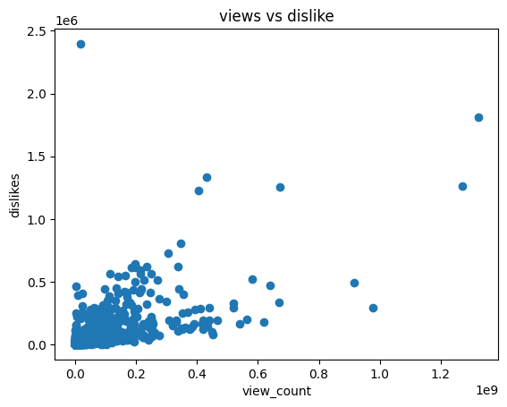

```python
import matplotlib.pyplot as plt
x=df['view_count']
y=df['dislikes']
plt.scatter(x,y)
plt.title('views vs dislike')
plt.xlabel('view_count')
plt.ylabel('dislikes')
plt.show()
```

```python
# getting correlation between columns 'view_count' and 'dislikes' using corr() method
df[['view_count','dislikes']].corr()
```

|  | view_count | dislikes |
| --- | --- | --- |
| view_count | 1.000000 | 0.684469 |
| dislikes | 0.684469 | 1.000000 |

INFERENCE: correlation for view count & dislikes is 0.684469 As the views count increases the number of dislike increases From the abovepointt we can state that the dislikes and views count has positiveproportionp

14. Display all the information about the videos that were published in January, and mention the count of videos that were published in January.

```python
# Displayed all the information about the videos that were published in January,

Jan_videos = df[df['published_month_name'] == 'January']
print("The Videos published in January are: ")
Jan_videos
```

```
The Videos published in January are:
```

|  | video_id | title | channel_id | channel_title | published_at | view_count | likes | dislikes | comment_count | tags | description | published_month | published_month_name |
| --- | --- | --- | --- | --- | --- | --- | --- | --- | --- | --- | --- | --- | --- |
| 27 | -2Gwm7QfBnE | Q&A With Naisha | UCYwNMbogQFzMccPSuy-pPWg | MianTwins | 2021-01-21 00:05:47 | 872372 | 38626 | 239 | 621 |  | Hey Guys!!! this has been the most requested v... | 1 | January |
| 48 | -4sfXSHSxzA | SURPRISING BRENT WITH HIS TIKTOK CRUSH!! | UCPpATKqmMV-CNRNWYaDUwiA | Alexa Rivera | 2021-01-16 21:40:04 | 6504784 | 262477 | 5779 | 7907 |  | He had no idea! Thank you guys so much for wat... | 1 | January |
| 95 | -AJD1Fc5rpQ | WE ARE HAVING A BABY! \| finding out i'm pregna... | UCVsTboAhpnuL6j-tDePvNwQ | Tess Christine | 2021-01-03 21:53:48 | 533084 | 38965 | 119 | 1650 |  | I am so happy to tell you that I am pregnant!!... | 1 | January |
| 103 | -AuJiwjsmWk | Do Ugly Foods Taste Worse? Taste Test | UCzpCc5n9hqiVC7HhPwcIKEg | Good Mythical MORE | 2021-01-19 11:00:01 | 1057077 | 22526 | 531 | 773 | gmm good mythical morning rhettandlink rhett a... | Today, we're doing a blind taste test to deter... | 1 | January |
| 182 | -JhqO2KWr5U | Schlatt gets fit | UCWZp4y1jqBuvLtiyxSs_ZBw | Big guy | 2021-01-24 22:50:57 | 1724965 | 119431 | 325 | 1578 | jschlatt big guy jschlatt highlights schlatt j... | #jschlatt #schlatt #bigguy #short | 1 | January |
| ... | ... | ... | ... | ... | ... | ... | ... | ... | ... | ... | ... | ... | ... |
| 37300 | zmzFL5bG-jc | DEVINE MON PERSONNAGE AVANT AKINATOR ! (c'est ... | UCIlr3byh6wmXgcPx_Tm9Ocw | Piwerre | 2021-01-16 16:12:19 | 670357 | 54462 | 832 | 1249 | Piwerre frere de michou crouton among us devin... | Discord Piwerre : https://discord.gg/QBduPgAA... | 1 | January |
| 37329 | zpzjex7qwrA | Lampard Sacked Within Days Rorys Misery \| Chel... | UCkD-ZOixI0a9FjIExDsHsbg | The Kick Off | 2021-01-03 20:13:49 | 428646 | 12060 | 296 | 1505 | Premier league Chelsea chelsea 1-3 Man City Ch... | The Kick Off watched Manchester City destroy C... | 1 | January |
| 37345 | zqyv-B6mnBM | Lil Wayne - Ain't Got Time (Audio) | UCO9zJy7HWrIS3ojB4Lr7Yqw | Lil Wayne | 2021-01-21 05:00:10 | 2238244 | 58925 | 2365 | 5539 | lil wayne weezy weezy wednesday wayne carter y... | Official audio for Lil Wayne "Ain't Got Time",... | 1 | January |
| 37383 | zwfu1-24T7Q | PRADA Cup Day 1 \| Full Race Replay \| PRADA Cup... | UCo15ZYO_XDRU9LI30OPtxAg | America's Cup | 2021-01-15 04:07:55 | 317382 | 2008 | 83 | 192 | America's Cup Americas Cup AC36 AC75 Presented... | The opening day of the PRADA Cup in Auckland, ... | 1 | January |
| 37418 | zziBybeSAtw | PELICANS at LAKERS \| FULL GAME HIGHLIGHTS \| Ja... | UCWJ2lWNubArHWmf3FIHbfcQ | NBA | 2021-01-16 05:39:05 | 2841917 | 20759 | 1049 | 2624 | NBA G League Basketball game-0022000187 Lakers... | PELICANS at LAKERS \| FULL GAME HIGHLIGHTS \| Ja... | 1 | January |

2108 rows × 13 columns

INFERENCE: The total number of videos uploaded on the month of january is 2108 which is referred from the shape of the above dataframe